# Homework 2

## 1.

```r
# library statements
# read in data
knitr::opts_chunk$set(echo = TRUE)
library(readr)
library(ggplot2)
library(dplyr)
library(tidymodels)
library(lubridate)
library(fabricatr)
tidymodels_prefer()

accidents <- read_csv("accident_cleanest.csv")
# how we cleaned the data

#  filter(year(Start_Time) >= 2018, year(Start_Time) <= 2019) %>%
#  drop_na(.) %>%
#  select( -Severity,  -Description, -Number, - Street, -Side, -County, -Zipcode, -Country, -Timezone, -Airport_Code, -Weather_Timestamp, -`Wind_Chill(F)`, -`Humidity(%)`, -`Pressure(in)`, -Wind_Direction, -`Precipitation(in)`, -Amenity, -Bump, -Give_Way, -No_Exit, -Railway, -Roundabout, - Station, -Stop, -Traffic_Calming, -Turning_Loop, -Civil_Twilight, -Nautical_Twilight, -Astronomical_Twilight) %>%
#  sample_frac(size = 1/5) %>%
#  mutate(Crossing = if_else(Crossing, 1, 0)) %>%
#  mutate(Junction = if_else(Junction, 1, 0)) %>%
#  mutate(Traffic_Signal = if_else(Traffic_Signal, 1, 0)) %>%
#  mutate(logDist = log(`Distance(mi)`+.1)) %>%
#  mutate(Duration = round(End_Time - Start_Time)) %>%
#  select(-`Distance(mi)`, - End_Time)
```

```r
# creation of cv folds
set.seed(253)

accident_cv <- vfold_cv(accidents, v = 10) # this is the random part

training(accident_cv$splits[[1]]) # pulls training data for the 1st split (1st fold is testing set)
```

```
## # A tibble: 9,508 × 20
##    ID        Start_Time          Start_Lat Start_Lng End_Lat End_Lng City  State
##    <chr>     <dttm>                  <dbl>     <dbl>   <dbl>   <dbl> <chr> <chr>
##  1 A-4217058 2019-07-07 14:55:52      39.5    -105.     39.5  -105.  Coni… CO
##  2 A-4214677 2019-07-01 19:40:52      27.6     -82.6    27.6   -82.6 Palm… FL
##  3 A-3912930 2019-02-19 12:58:00      40.9    -112.     40.9  -112.  Boun… UT
##  4 A-4201636 2019-06-18 13:11:54      30.3     -98.0    30.3   -98.0 Lake… TX
##  5 A-4225487 2019-07-25 08:31:02      32.5     -85.1    32.5   -85.1 Smit… AL
##  6 A-3810776 2019-10-19 01:24:00      37.1    -122.     37.1  -122.  Felt… CA
##  7 A-4203920 2019-06-24 18:04:27      35.1     -77.0    35.1   -77.0 New … NC
##  8 A-3879496 2019-09-12 19:18:46      45.3    -123.     45.3  -123.  Newb… OR
##  9 A-3877622 2019-09-10 17:00:00      34.0    -119.     34.0  -119.  Mali… CA
## 10 A-3782429 2019-12-18 18:05:51      31.2     -81.7    31.2   -81.7 Brun… GA
## # … with 9,498 more rows, and 12 more variables: Temp <dbl>, Vis <dbl>,
## #   Wind <dbl>, Weather_Condition <chr>, Crossing <dbl>, Junction <dbl>,
## #   Traffic_Signal <dbl>, Sunrise_Sunset <chr>, logDist <dbl>, Duration <dbl>,
## #   dayofweek <dbl>, month <dbl>
```

```r
testing(accident_cv$splits[[1]]) # pulls testing data for the 1st split (1st fold is testing set)
```

```
## # A tibble: 1,057 × 20
##    ID        Start_Time          Start_Lat Start_Lng End_Lat End_Lng City  State
##    <chr>     <dttm>                  <dbl>     <dbl>   <dbl>   <dbl> <chr> <chr>
##  1 A-3810498 2019-10-19 00:44:00      41.5    -121.     41.5  -121.  Altu… CA
##  2 A-3801964 2019-10-12 11:05:00      34.6    -120.     34.6  -120.  Sant… CA
##  3 A-4171474 2019-04-16 15:51:24      41.3     -73.7    41.3   -73.7 Nort… NY
##  4 A-3810211 2019-10-19 20:46:00      43.7     -95.5    43.7   -95.5 Brew… MN
##  5 A-3833167 2019-11-05 17:01:58      44.1    -124.     44.0  -124.  Flor… OR
##  6 A-4216524 2019-07-05 12:37:25      43.8    -121.     43.8  -121.  Bend  OR
##  7 A-4207846 2019-08-25 13:40:05      33.7     -84.3    33.7   -84.3 Atla… GA
##  8 A-4229955 2019-08-03 05:35:00      37.6    -113.     37.6  -113.  Ceda… UT
##  9 A-3837649 2019-11-08 07:52:10      44.0    -124.     44.0  -124.  Noti  OR
## 10 A-3915786 2019-02-24 15:44:26      43.7    -123.     43.7  -123.  Drain OR
## # … with 1,047 more rows, and 12 more variables: Temp <dbl>, Vis <dbl>,
## #   Wind <dbl>, Weather_Condition <chr>, Crossing <dbl>, Junction <dbl>,
## #   Traffic_Signal <dbl>, Sunrise_Sunset <chr>, logDist <dbl>, Duration <dbl>,
## #   dayofweek <dbl>, month <dbl>
```

1. Use ordinary least squares (OLS) by using the `lm` engine and LASSO (`glmnet` engine) to build a series of initial regression models for your quantitative outcome as a function of the predictors of interest. (As part of data cleaning, exclude any variables that you don’t want to consider as predictors.)
- You’ll need two model specifications, `lm_spec` and `lm_lasso_spec` (you’ll need to tune this one).

```r
# model specifications
lm_spec <-
    linear_reg() %>%
    set_engine(engine = 'lm') %>%
    set_mode('regression')

lm_lasso_spec <-
    linear_reg() %>%
    set_args(mixture = 1, penalty = tune()) %>%
    set_engine(engine = 'glmnet') %>%
    set_mode('regression')

knn_spec <-
  nearest_neighbor() %>% # new type of model!
  set_args(neighbors = tune()) %>% # tuning parameter is neighbor; tuning spec
  set_engine(engine = 'kknn') %>% # new engine
  set_mode('regression')
```

2. For each set of variables, you’ll need a `recipe` with the `formula`, `data`, and pre-processing steps
- You may want to have steps in your recipe that remove variables with near zero variance (`step_nzv()`), remove variables that are highly correlated with other variables (`step_corr()`), normalize all quantitative predictors (`step_normalize(all_numeric_predictors())`) and add indicator variables for any categorical variables (`step_dummy(all_nominal_predictors())`).
- These models should not include any transformations to deal with nonlinearity. You’ll explore this in the next investigation.

```r
# recipes & workflows

car_rec <- recipe(logDist ~ Vis + Temp + Wind + Weather_Condition + Crossing + Junction + Traffic_Signal + Sunrise_Sunset + Duration + dayofweek + Start_Time, data = accidents) %>%
    step_nzv(all_predictors()) %>%
    step_other(all_nominal_predictors()) %>%
    step_normalize(all_numeric_predictors()) %>%
    step_dummy(all_nominal_predictors())

model_wf <- workflow() %>%
    add_recipe(car_rec) %>%
    add_model(lm_spec)

fit_model <- model_wf %>% fit(data = accidents)

car_rec %>% prep(accidents) %>% juice()
```

```
## # A tibble: 10,565 × 14
##      Temp     Wind Crossing Traffic_Signal Duration dayofweek
##     <dbl>    <dbl>    <dbl>          <dbl>    <dbl>     <dbl>
##  1  1.23   0.369     -0.308         -0.430 -0.0386     -1.63
##  2  1.39   0.549     -0.308         -0.430 -0.0386     -1.09
##  3 -1.92   0.405     -0.308         -0.430 -0.0332     -0.559
##  4  1.29   0.369     -0.308         -0.430 -0.0384     -0.559
##  5  0.867  0.00864   -0.308         -0.430 -0.0382      0.512
##  6 -0.817 -0.171     -0.308         -0.430 -0.0375      1.58
##  7 -0.554 -0.171     -0.308         -0.430 -0.0286      1.58
##  8  1.50   0.549     -0.308         -0.430 -0.0382     -1.09
##  9  0.867 -0.171     -0.308         -0.430  0.00731     0.512
## 10  0.709 -0.711     -0.308         -0.430 -0.0284      1.58
## # … with 10,555 more rows, and 8 more variables: Start_Time <dttm>,
## #   logDist <dbl>, Weather_Condition_Fair <dbl>,
## #   Weather_Condition_Light.Rain <dbl>, Weather_Condition_Mostly.Cloudy <dbl>,
## #   Weather_Condition_Partly.Cloudy <dbl>, Weather_Condition_other <dbl>,
## #   Sunrise_Sunset_Night <dbl>
```

```r
lasso_wf_car <- workflow() %>%
    add_recipe(car_rec) %>%
    add_model(lm_lasso_spec)

knn_wf <- workflow() %>%
  add_model(knn_spec) %>%
  add_recipe(car_rec)
```

```r
#fit & tune models
mod1_cv <- fit_resamples(model_wf,
                         resamples = accident_cv,
                         metrics = metric_set(rmse, rsq, mae))

penalty_grid <- grid_regular(
  penalty(range = c(-3, 1)), #log10 transformed
  levels = 30)

tune_output <- tune_grid( # new function for tuning parameters
  lasso_wf_car, # workflow
  resamples = accident_cv, # cv folds
  metrics = metric_set(rmse, mae),
  grid = penalty_grid # penalty grid defined above
)

best_se_penalty <- select_by_one_std_err(tune_output, metric = 'mae', desc(penalty))
best_se_penalty # choose penalty value based on the largest penalty within 1 se of the lowest CV MAE

best_penalty <- select_best(tune_output, metric = 'mae')
best_penalty # choose penalty value based on lowest mae

autoplot(tune_output) + theme_classic()

final_wf <- finalize_workflow(lasso_wf_car, best_penalty) # incorporates penalty value to workflow
final_wf_se <- finalize_workflow(lasso_wf_car, best_se_penalty)

final_fit <- fit(final_wf, data = accidents)
final_fit_se <- fit(final_wf_se, data = accidents)

tidy(final_fit)
tidy(final_fit_se) %>% arrange(desc(abs(estimate)))
```

[output not shown]

3. Estimate the test performance of the models using CV. Report and interpret (with units) the CV metric estimates along with a measure of uncertainty in the estimate (`std_error` is readily available when you used `collect_metrics(summarize=TRUE)`).
- Compare estimated test performance across the models. Which models(s) might you prefer?

```r
#  calculate/collect CV metrics
mod1_cv %>% collect_metrics()
```

[output not shown]

4. Use residual plots to evaluate whether some quantitative predictors might be better modeled with nonlinear relationships.

```r
# visual residuals

#how do we do this?
mod1_output <- final_fit_se %>%
    predict(new_data = accidents) %>% #this function maintains the row order of the new_data
    bind_cols(accidents) %>%
    mutate(resid = logDist - .pred)

mod1_output %>%
  ggplot(aes(x = .pred, y = resid)) +
  geom_point() +
  geom_smooth() +
  geom_hline(yintercept = 0) +
  theme_classic()

mod1_output %>%
  ggplot(aes(x = Temp, y = resid)) +
  geom_point() +
  geom_smooth() +
  geom_hline(yintercept = 0) +
  theme_classic()

mod1_output %>%
  ggplot(aes(x = Vis, y = resid)) +
  geom_point() +
  geom_smooth() +
  geom_hline(yintercept = 0) +
  theme_classic()

mod1_output %>%
  ggplot(aes(x = Wind, y = resid)) +
  geom_point() +
  geom_smooth() +
  geom_hline(yintercept = 0) +
  theme_classic()

mod1_output %>%
  ggplot(aes(x = Precip, y = resid)) +
  geom_point() +
  geom_smooth() +
  geom_hline(yintercept = 0) +
  theme_classic()

mod1_output %>%
  ggplot(aes(x = dayofweek, y = resid)) +
  geom_point() +
  geom_smooth() +
  geom_hline(yintercept = 0) +
  theme_classic()

mod1_output %>%
  ggplot(aes(x = month, y = resid)) +
  geom_point() +
  geom_smooth() +
  geom_hline(yintercept = 0) +
  theme_classic()
```

[output not shown]

5. Which variables do you think are the most important predictors of your quantitative outcome? Justify your answer. Do the methods you’ve applied reach consensus on which variables are most important? What insights are expected? Surprising?
- Note that if some (but not all) of the indicator terms for a categorical predictor are selected in the final models, the whole predictor should be treated as selected.

## 2.

**Summarize investigations** - Decide on an overall best model based on your investigations so far. To do this, make clear your analysis goals. Predictive accuracy? Interpretability? A combination of both?

## 3.

**Societal impact** Are there any harms that may come from your analyses and/or how the data were collected?

One element of the way data was collected that may be harmful is the fact that this information is collected from API’s from Mapquest and Bing which would be tracking live traffic. A lot of the time, this traffic is collected from users of the apps which many times do not realize they have consented to allowing their location information to be collected. As a result, information on traffic duration is made up of individuals who may not want to contribute to the research. Similarly, another harm of the dataset could be the possible inclusion of multiples when recording the accidents. The data collectors took measures to filter out any duplicates, but there is a possibility that there are still some left in that could affect the integrity of our results.

What cautions do you want to keep in mind when communicating your work?

# Homework 3

## 2.

**Accounting for nonlinearity** a. Update your OLS model(s) and LASSO model to use natural splines for the quantitative predictors. -You’ll need to update the recipe to include step_ns() for each quantitative predictor. -It’s recommended to use few knots (e.g., 2 knots = 3 degrees of freedom).

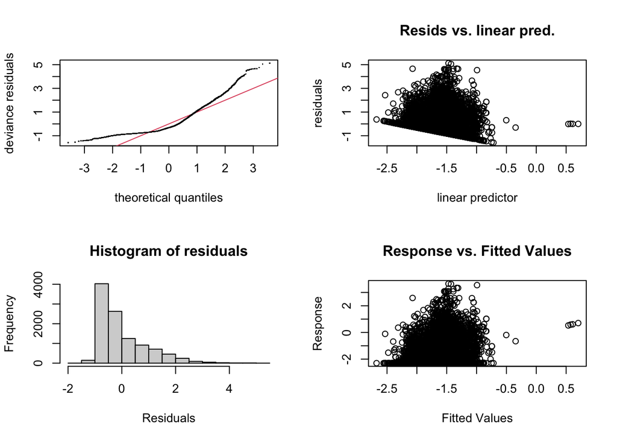

```
##
## Method: GCV   Optimizer: magic
## Smoothing parameter selection converged after 7 iterations.
## The RMS GCV score gradient at convergence was 2.413058e-07 .
## The Hessian was positive definite.
## Model rank =  74 / 74
##
## Basis dimension (k) checking results. Low p-value (k-index<1) may
## indicate that k is too low, especially if edf is close to k'.
##
##            k'   edf k-index p-value
## s(Vis)   9.00  5.37    1.00    0.54
## s(Temp) 10.00  6.70    0.99    0.27
```

```r
gam_spec <-
  gen_additive_mod() %>%
  set_engine(engine = 'mgcv') %>%
  set_mode('regression')

gam_mod <- fit(gam_spec,
               logDist ~ s(Vis) + s(Temp,k=11) + Wind + Weather_Condition + Crossing + Junction + Traffic_Signal + Sunrise_Sunset,
               data = accidents)

par(mfrow=c(2,2))
gam_mod %>% pluck('fit') %>% mgcv::gam.check()
```

```r
gam_mod %>% pluck('fit') %>% summary()
```

```
##
## Family: gaussian
## Link function: identity
##
## Formula:
## logDist ~ s(Vis) + s(Temp, k = 11) + Wind + Weather_Condition +
##     Crossing + Junction + Traffic_Signal + Sunrise_Sunset
##
## Parametric coefficients:
##                                                Estimate Std. Error t value
## (Intercept)                                   -2.518920   0.918986  -2.741
## Wind                                           0.009277   0.001908   4.862
## Weather_ConditionBlowing Snow                  1.661464   1.126008   1.476
## Weather_ConditionClear                         1.420298   0.982157   1.446
## Weather_ConditionCloudy                        0.950647   0.918782   1.035
## Weather_ConditionCloudy / Windy                0.893548   0.930241   0.961
## Weather_ConditionDrizzle                       1.105250   0.950940   1.162
## Weather_ConditionFair                          0.833399   0.918647   0.907
## Weather_ConditionFair / Windy                  0.792071   0.924449   0.857
## Weather_ConditionFog                           0.886798   0.924039   0.960
## Weather_ConditionFog / Windy                   0.177052   1.028399   0.172
## Weather_ConditionHaze                          0.832420   0.923118   0.902
## Weather_ConditionHaze / Windy                  0.112387   1.299178   0.087
## Weather_ConditionHeavy Rain                    1.586484   0.941958   1.684
## Weather_ConditionHeavy Rain / Windy            0.447818   1.125913   0.398
## Weather_ConditionHeavy Snow                    1.635929   0.957873   1.708
## Weather_ConditionHeavy T-Storm                 1.523682   1.299509   1.173
## Weather_ConditionHeavy T-Storm / Windy         0.603355   1.299856   0.464
## Weather_ConditionHeavy Thunderstorms and Rain  3.145551   1.299748   2.420
## Weather_ConditionLight Blowing Snow            3.136748   1.299171   2.414
## Weather_ConditionLight Drizzle                 1.220945   0.933437   1.308
## Weather_ConditionLight Drizzle / Windy         0.904679   1.299561   0.696
## Weather_ConditionLight Freezing Drizzle        2.149798   1.125950   1.909
## Weather_ConditionLight Freezing Fog            0.601206   1.128410   0.533
## Weather_ConditionLight Freezing Rain           1.350171   0.954255   1.415
## Weather_ConditionLight Ice Pellets             1.667792   1.027817   1.623
## Weather_ConditionLight Rain                    1.067535   0.919358   1.161
## Weather_ConditionLight Rain / Windy            0.691616   0.938542   0.737
## Weather_ConditionLight Rain with Thunder       1.209027   0.950579   1.272
## Weather_ConditionLight Snow                    1.352624   0.921212   1.468
```

[output cut: 78 more lines]

```
## Junction                                      0.056839 .
## Traffic_Signal                                 < 2e-16 ***
## Sunrise_SunsetNight                           0.232033
## ---
## Signif. codes:  0 '***' 0.001 '**' 0.01 '*' 0.05 '.' 0.1 ' ' 1
##
## Approximate significance of smooth terms:
##           edf Ref.df      F p-value
## s(Vis)  5.372  6.401 10.663  <2e-16 ***
## s(Temp) 6.702  7.847  7.775  <2e-16 ***
## ---
## Signif. codes:  0 '***' 0.001 '**' 0.01 '*' 0.05 '.' 0.1 ' ' 1
##
## R-sq.(adj) =  0.0628   Deviance explained = 6.87%
## GCV = 0.84806  Scale est. = 0.84267   n = 10565
```

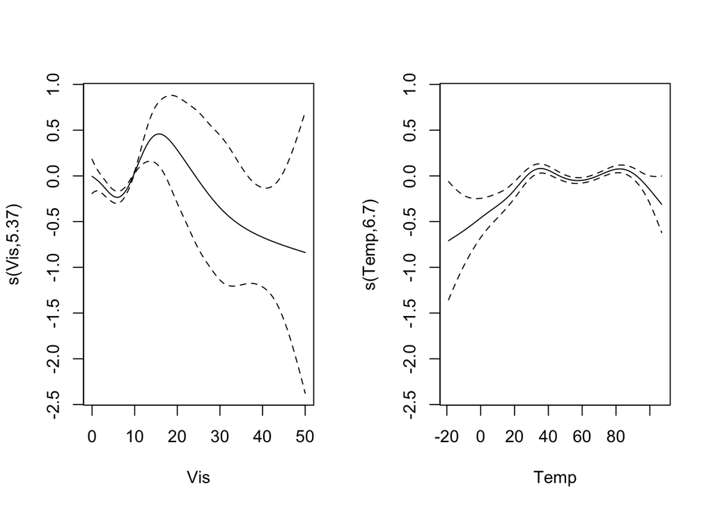

```r
gam_mod %>% pluck('fit') %>%plot( page = 1)
```

```r
spline_rec <- recipe(logDist ~ ., data = accidents) %>%
  step_rm(ID) %>%
  #step_rm(`Weather_Condition_Partly.Cloudy`) %>%
  step_other(all_nominal_predictors()) %>%
  step_dummy(all_nominal_predictors())

  #step_ns(Terminal, deg_free = 3) %>%
  #step_ns(Expend, deg_free = 3) #ask Brianna about what we need

# Check the pre-processed data
spline_rec %>% prep(accidents) %>% juice() #why did ID show up? How to analyze? How do we know which ones to do stepns for?
```

```
## # A tibble: 10,565 × 26
##    Start_Time          Start_Lat Start_Lng End_Lat End_Lng  Temp   Vis  Wind
##    <dttm>                  <dbl>     <dbl>   <dbl>   <dbl> <dbl> <dbl> <dbl>
##  1 2019-07-07 14:55:52      39.5    -105.     39.5  -105.     83    10   9
##  2 2019-07-01 19:40:52      27.6     -82.6    27.6   -82.6    86    10  10
##  3 2019-02-19 12:58:00      40.9    -112.     40.9  -112.     23     2   9.2
##  4 2019-06-18 13:11:54      30.3     -98.0    30.3   -98.0    84    10   9
##  5 2019-07-25 08:31:02      32.5     -85.1    32.5   -85.1    76    10   7
##  6 2019-10-19 00:44:00      41.5    -121.     41.5  -121.     44    10   6
##  7 2019-10-19 01:24:00      37.1    -122.     37.1  -122.     49    10   6
##  8 2019-06-24 18:04:27      35.1     -77.0    35.1   -77.0    88    10  10
##  9 2019-09-12 19:18:46      45.3    -123.     45.3  -123.     76    10   6
## 10 2019-10-12 11:05:00      34.6    -120.     34.6  -120.     73    10   3
## # … with 10,555 more rows, and 18 more variables: Crossing <dbl>,
## #   Junction <dbl>, Traffic_Signal <dbl>, Duration <dbl>, dayofweek <dbl>,
## #   month <dbl>, logDist <dbl>, City_other <dbl>, State_MN <dbl>,
## #   State_OR <dbl>, State_UT <dbl>, State_other <dbl>,
## #   Weather_Condition_Fair <dbl>, Weather_Condition_Light.Rain <dbl>,
## #   Weather_Condition_Mostly.Cloudy <dbl>,
## #   Weather_Condition_Partly.Cloudy <dbl>, Weather_Condition_other <dbl>, …
```

```r
# How do we know which predictors are the most relevant?
```

```r
lm_spec <-
  linear_reg() %>%
  set_engine(engine = 'lm') %>%
  set_mode('regression')

# Workflow (Recipe + Model)
spline_wf <- workflow() %>%
  add_recipe(spline_rec) %>%
  add_model(lm_spec)


# CV to Evaluate
cv_output <- fit_resamples(
  spline_wf, # workflow
  resamples =accident_cv, # cv folds
  metrics = metric_set(mae)
)
cv_output %>% collect_metrics()
```

```
## # A tibble: 1 × 6
##   .metric .estimator  mean     n std_err .config
##   <chr>   <chr>      <dbl> <int>   <dbl> <chr>
## 1 mae     standard   0.562    10 0.00387 Preprocessor1_Model1
```

```r
# Fit model
ns_mod <- spline_wf %>%
  fit(data = accidents)

ns_mod %>%
  tidy() %>%
  arrange(desc(p.value))
```

```
## # A tibble: 26 × 5
##    term                             estimate std.error statistic p.value
##    <chr>                               <dbl>     <dbl>     <dbl>   <dbl>
##  1 Weather_Condition_Mostly.Cloudy -0.00382   0.0313      -0.122  0.903
##  2 Vis                              0.000658  0.00374      0.176  0.860
##  3 Weather_Condition_other          0.00861   0.0350       0.246  0.806
##  4 City_other                      -0.0334    0.0438      -0.763  0.445
##  5 Weather_Condition_Partly.Cloudy  0.0410    0.0305       1.34   0.180
##  6 Junction                         0.107     0.0702       1.53   0.126
##  7 Temp                             0.000916  0.000565     1.62   0.105
##  8 Wind                            -0.00259   0.00152     -1.71   0.0879
##  9 Weather_Condition_Fair           0.0412    0.0232       1.78   0.0757
## 10 dayofweek                       -0.00777   0.00413     -1.88   0.0596
## # … with 16 more rows
```

2. Compare insights from variable importance analyses here and the corresponding results from the Investigation 1. Now after having accounted for nonlinearity, have the most relevant predictors changed? -Note that if some (but not all) of the spline terms are selected in the final models, the whole predictor should be treated as selected.

### we didn’t get past this… we have to redo some of the part 1 code as we standardized some variables; but have all reached our capacity for this assignment and want to enjoy break.

3. Fit a GAM using spline terms using the set of variables deemed to be most relevant based on your investigations so far. -How does test performance of the GAM compare to other models you explored? -Do you gain any insights from the GAM output plots for each predictor?
3. Summarize investigations -Decide on an overall best model based on your investigations so far. To do this, make clear your analysis goals. Predictive accuracy? Interpretability? A combination of both?
4. Societal impact -Are there any harms that may come from your analyses and/or how the data were collected? -What cautions do you want to keep in mind when communicating your work?

# Homework 4

Specify the research question for a classification task.

**What factors best predict whether an accident’s impact on traffic is low, medium or high?**

Try to implement at least 2 different classification methods to answer your research question.

```r
# splitting distance into low, medium and high
# these will be two different log graphs—low to med and med to high

accidents %>%
  mutate(distRank = ntile(accidents$logDist, 3)) %>%
  mutate(distRank = relevel(factor(distRank), ref = 1)) %>%
  filter(distRank %in% c(1,2)) -> lowMedDist  #compares low to medium distance

accidents %>%
  mutate(distRank = ntile(accidents$logDist, 3)) %>%
  mutate(distRank = relevel(factor(distRank), ref = 2)) %>%
  filter(distRank %in% c(2,3)) -> medHighDist #compares medium to high distance

# CV Folds for each
lowMed_cv10 <- vfold_cv(lowMedDist, v = 10)
medHigh_cv10 <- vfold_cv(medHighDist, v = 10)

# Tuning Specification
logistic_lasso_spec_tune <- logistic_reg() %>%
    set_engine('glmnet') %>%
    set_args(mixture = 1, penalty = tune()) %>%
    set_mode('classification')
```

```r
# for lowMed subset:

# Recipe
logistic_rec <- recipe(distRank ~ Start_Time, Duration, dayofweek, Temp,
                       Vis, Wind, Weather_Condition, Crossing, Junction,
                       Traffic_Signal, Sunrise_Sunset,
                       data = lowMedDist) %>%
    step_normalize(all_numeric_predictors()) %>%
    step_other(all_nominal_predictors()) %>%
    step_dummy(all_nominal_predictors())

# Workflow (Recipe + Model)
log_lasso_wf <- workflow() %>%
    add_recipe(logistic_rec) %>%
    add_model(logistic_lasso_spec_tune)

# Tune Model
penalty_grid <- grid_regular(
  penalty(range = c(-3, 1)), #log10 transformed
  levels = 30)

# Tune Output
#tune_output <- tune_grid(
#  log_lasso_wf, # workflow
#  resamples = lowMed_cv10, # cv folds
#  metrics = metric_set(roc_auc),
#  control = control_resamples(save_pred = TRUE, event_level = 'second'),
#  grid = penalty_grid # penalty grid defined above
#)

# Tune Output results in an error, unsure why but we predict it is a problem with the formatting of our categorical variables
```

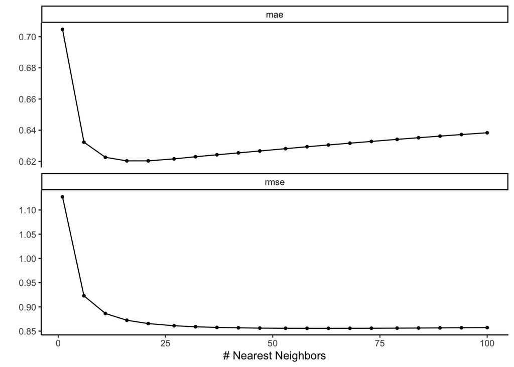

```r
penalty_grid <- grid_regular(
  neighbors(range = c(1, 100)), #  min and max of values for neighbors
  levels = 20) # number of neighbors values
knn_fit_cv <- tune_grid(knn_wf, # workflow
              resamples = accident_cv, #CV folds
              grid = penalty_grid, # grid specified above
              metrics = metric_set(rmse, mae))

knn_fit_cv %>% autoplot() + theme_classic()
```

```r
knn_fit_cv %>% show_best(metric = 'mae')
```

```
## # A tibble: 5 × 7
##   neighbors .metric .estimator  mean     n std_err .config
##       <int> <chr>   <chr>      <dbl> <int>   <dbl> <chr>
## 1        16 mae     standard   0.620    10 0.00721 Preprocessor1_Model04
## 2        21 mae     standard   0.620    10 0.00675 Preprocessor1_Model05
## 3        27 mae     standard   0.622    10 0.00630 Preprocessor1_Model06
## 4        11 mae     standard   0.623    10 0.00766 Preprocessor1_Model03
## 5        32 mae     standard   0.623    10 0.00602 Preprocessor1_Model07
```

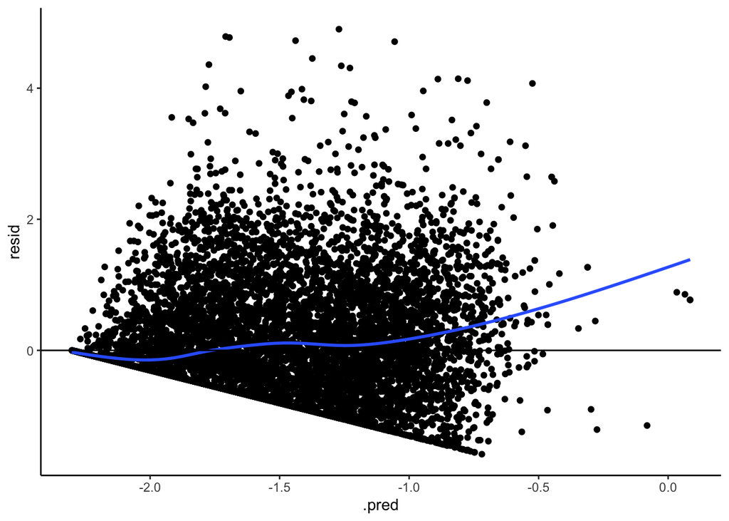

```r
tuned_knn_wf <- knn_fit_cv %>%
  select_by_one_std_err(metric = 'mae', desc(neighbors)) %>%  # Choose neighbors value that leads to the highest neighbors within 1 se of the lowest CV MAE
  finalize_workflow(knn_wf, .)

# Fit final KNN model to data
knn_fit_final <- tuned_knn_wf %>%
  fit(data = accidents)

#--------------------

knn_mod_out <- knn_fit_final %>%
    predict(new_data = accidents) %>%
    bind_cols(accidents) %>%
    mutate(resid = logDist - .pred)

knn_mod_out %>%
  ggplot(aes(x = .pred, y = resid)) +
  geom_point() +
  geom_smooth(se = FALSE) +
  geom_hline(yintercept = 0) +
  theme_classic()
```

Reflect on the information gained from these two methods and how you might justify this method to others.

Keep in mind that the final project will require you to complete the pieces below. Use this as a guide for your work but don’t try to accomplish everything for HW4:

Classification - Methods Indicate at least 2 different methods used to answer your classification research question. Describe what you did to evaluate the models explored. Indicate how you estimated quantitative evaluation metrics. Describe the goals / purpose of the methods used in the overall context of your research investigations.

Classification - Results Summarize your final model and justify your model choice (see below for ways to justify your choice). Compare the different classification models tried in light of evaluation metrics, variable importance, and data context. Display evaluation metrics for different models in a clean, organized way. This display should include both the estimated metric as well as its standard deviation. (This won’t be available from OOB error estimation. If using OOB, don’t worry about reporting the SD.) Broadly summarize conclusions from looking at these evaluation metrics and their measures of uncertainty.

Classification - Conclusions - Interpret evaluation metric(s) for the final model in context. Does the model show an acceptable amount of error? - If using OOB error estimation, display the test (OOB) confusion matrix, and use it to interpret the strengths and weaknesses of the final model. - Summarization should show evidence of acknowledging the data context in thinking about the sensibility of these results.